# ADA (week 8) Introduction to Stan: Self-practice & homework exercises

# Exercise 4 [BONUS]: Jointly inferring infection rate, false positive and false negative rates for Covid-19 tests

This exercise is (loosely) arranged around an [existing research report on Covid-19 infection rates](https://www.medrxiv.org/content/10.1101/2020.04.14.20062463v2). The original paper pools data from several sources. We will not look at the specifics, but rather use the example to make a point about the benefits of writing custom Bayesian models, even simple ones, to learn from multiple sources of data simultaneously and to infer several unknowns at the same time, a so-called joint-inference model.

Suppose we have a test, stupidly called C-64 here, to detect if a person has Covid-19. (We assume, probably falsely, that having or not having Covid-19 is a binary variable at any given point in time.) We want to use the C-64 test to infer the overall (latent) current infection rate in the population. The population is assumed to be so large that we treat it as infinite for practical purposes.

## 4.a Write a simple Binomial model in Stan

If the C-64 test is completely reliable, we could sample $n_\text{sampled}$ people from the population, test them with C-64 and infer the latent infection rate $p_\text{infected}$ as using a simple binomial model, were $k_\text{positest}$ is the number of observed positive test results in our sample of $n_\text{sampled}$:

```stan
data {
  int k_sampled;
  int n_sampled;
}
parameters {
  real<lower = 0, upper = 1> p_infected;
}
model {
  // priors
  p_infected ~ beta(1,1);
  // likelihood of data
  // ... your code here ...
}
```

Feed the following data into the program and show a summary statistic for the model’s parameter values. What is a credible range of the crucial parameter `p_infected` (use the quantiles from the stanfit summary to approximate the 95% HDI).

```r
data_list_4a = list(
  k_sampled = 50,    n_sampled = 3330
)
```

## 4.b Include uncertainty about specificity and sensitivity of the test

The problem with the C-64 test is that it is not perfect. It will yield positive test results indicating the infection when in fact there is none (false positives). It will also yield negative test results indicating no infection when in fact there is one (false negatives).

Consequently, the problem with our analysis above is that it is naive. More crucially, we might not know how good or bad our test is. This is what calls for a Bayesian analysis: we are going to jointly infer, not only the infection rate in the population, but also the sensitivity and the specificity of the test, where:

- **sensititvity** of a test is the probability of getting a positive test result when in fact the disease is present
- **specificity** of a test is the probability of getting a negative test result when in fact the disease is absent

We will use data from the original research, which also contain information on the likely sensitivity and specificity of the test in question (which is *not* actually called C-64, but is a measure of seroprevalence of antibodies to SARS-CoV-2 based on lateral flow immunoassay). In particular, we will use the following data:

```r
data_list_4b = list(
  k_sampled = 50,    n_sampled = 3330,
  k_sens = 103,      n_sens = 122,
  k_spec = 399,      n_spec = 401
)
```

We assume that $k_\text{sens}$ and $k_\text{spec}$ are the result of a binomial process whose true latent parameters are C-64’s actual sensitivity $p_\text{sens}$ and specificity $p_\text{spec}$.

This way, we obtain the following full joint-inference model:

Notice in particular, that the latent probability of obtaining a positive test result is a deterministic function of the unknown parameters $p_\text{infected}$, $p_\text{spec}$ and $p_\text{sens}$:

$$p_\text{positest} = p_\text{infected} \ p_\text{sens} + (1- p_\text{infected}) \ (1 - p_\text{spec})$$

Here is also a graphical representation of the main relationships between variables in this model.

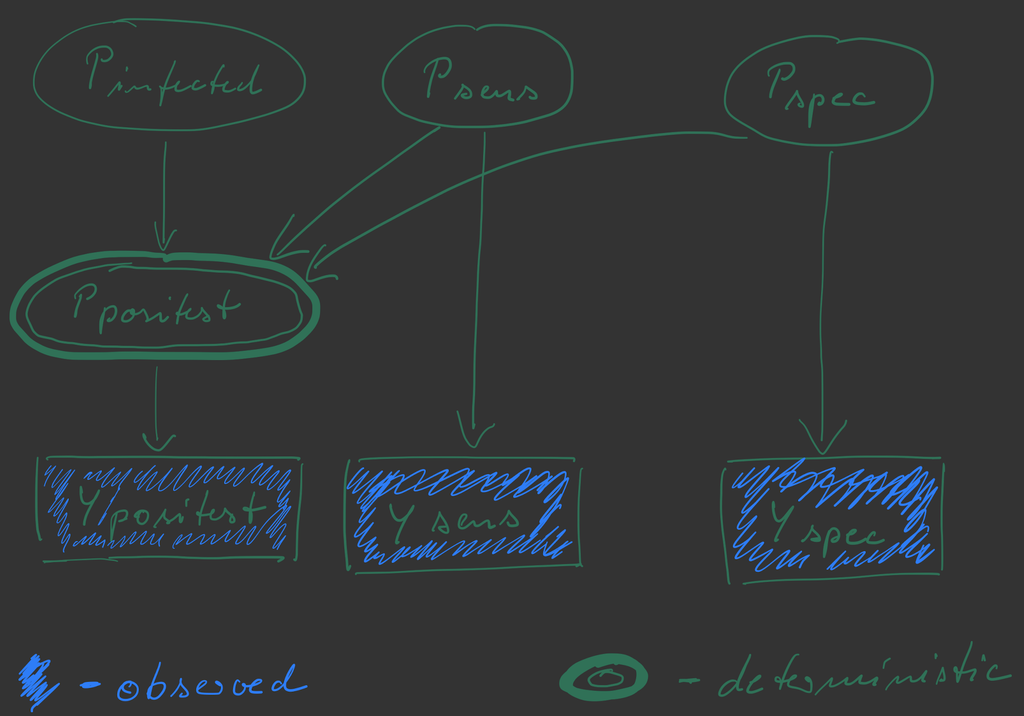

Implement this model in Stan, run it, and compare the estimates of the true infection rate in the population to the estimates of the naive model we saw before. Explain any observed differences in the inference in terms of the estimates of `p_sens` and `p_spec`.